# Lesson 1: Visualizing data with *ggplot2*

Published

October 19, 2023

# 1 Prepare the R environment for this lesson

When we start R, we only have access to the **base R** packages. In order to use any additional packages, we need to load them into memory with the `library()` function.

```r
library(ggplot2)
library(palmerpenguins)
```

It’s good practice to start R code, stored in R scripts or quarto/Rmarkdown documents, by loading the packages we’ll be using in the body of the code. It gives readers, including future versions of ourselves, a consistent place to check all of the packages required to run our code.

# 2 A note about functions

Functions are how we do everything in R. This includes simple procedures, like calculating the sum of three numbers, and more complex operations, like performing a linear regression and plotting the resulting regression line against the input data. Above, we saw an example of the general convention for writing functions in R: `function_name(arguments)`. Generally speaking, a function’s **arguments** provide it with input and can control how it runs.

# 3 R Documentation

When we download and install a package from CRAN, we’re also downloading documentation pages that describe how to run each function in the package.

In RStudio, we can access the documentation through the *Help* tab, located in the lower right pane of the RStudio window. Let’s use the `sum()` function as an example. To access the documentation pages for the `sum()` function:

1. Click the *Help* tab in the lower right pane of the RStudio window.
2. Click the search box in the upper right corner of the *Help* tab.
3. Type “sum” in the search bar. Note, we don’t include the parentheses after the function name when we’re searching for documentation.
4. Press “Enter”

The documentation page for the `sum()` function should appear in the *Help* pane. It contains several sections describing what the function does, the names of its arguments and how they work, and the output of the function. The very end of the documentation page also contains example code that we can run to get a better feel for how the function works (these are very useful).

We can also access these same help pages directly through the R console by using the `help()` function, or the “?” operator.

```r
help("sum")
```

```r
?sum
```

When learning about a new function, it’s often most helpful to pay special attention to the usage, arguments, and examples sections of the function’s documentation page.

**Keep Using the *Help* Tab**

As we proceed through these materials, don’t hesitate to use the help feature whenever we encounter a new function.

# 4 Plotting penguins

## 4.1 Look at the Palmer Penguins data table

After loading the *palmerpenguins* package, we now have access to table of penguin data. We can view the first 10 lines of this table directly in the R console:

```r
penguins
```

```
# A tibble: 344 × 8
   species island    bill_length_mm bill_depth_mm flipper_length_mm body_mass_g
   <fct>   <fct>              <dbl>         <dbl>             <int>       <int>
 1 Adelie  Torgersen           39.1          18.7               181        3750
 2 Adelie  Torgersen           39.5          17.4               186        3800
 3 Adelie  Torgersen           40.3          18                 195        3250
 4 Adelie  Torgersen           NA            NA                  NA          NA
 5 Adelie  Torgersen           36.7          19.3               193        3450
 6 Adelie  Torgersen           39.3          20.6               190        3650
 7 Adelie  Torgersen           38.9          17.8               181        3625
 8 Adelie  Torgersen           39.2          19.6               195        4675
 9 Adelie  Torgersen           34.1          18.1               193        3475
10 Adelie  Torgersen           42            20.2               190        4250
# ℹ 334 more rows
# ℹ 2 more variables: sex <fct>, year <int>
```

Each row in this table contains data from a single penguin measurement during the study period. Looking at the columns, we see all of the different information the researchers recorded about each penguin. We can also see that there are observations with missing information, represented by `NA` values. In R terminology, this is called a *data frame*. It is a natural way of representing rectangular, spreadsheet-style data. The penguin data are technically stored as a *tibble*, which is a special type of data frame used by the tidyverse.

The *palmerpenguins* package also contains documentation for the penguin data frame. Look up “penguins” using the *Help* pane, or one of the other help functions. The documentation describes the contents of each column in the data frame.

In addition to viewing the data frame in the R console, we can use the `View()` function to quickly examine its contents in a scrollable, spreadsheet-style window.

```r
View(penguins)
```

Inside the view window, we can search the data frame for specific values, or re-order it by values in each of the columns. While the `View()` function is useful for smaller datasets, it is not generally suitable for data frames with more than a few thousand rows.

**The “V” in the `View()` function is capitalized**

If we try to use the `View()` function with a lower case “v”, we’ll generally get an error:

```r
view(penguins)
```

```
Error in view(penguins): could not find function "view"
```

Lastly, we can use the `summary()` function to get summary statistics about the data in each column of our data frame.

```r
summary(penguins)
```

```
      species          island    bill_length_mm  bill_depth_mm
 Adelie   :152   Biscoe   :168   Min.   :32.10   Min.   :13.10
 Chinstrap: 68   Dream    :124   1st Qu.:39.23   1st Qu.:15.60
 Gentoo   :124   Torgersen: 52   Median :44.45   Median :17.30
                                 Mean   :43.92   Mean   :17.15
                                 3rd Qu.:48.50   3rd Qu.:18.70
                                 Max.   :59.60   Max.   :21.50
                                 NA's   :2       NA's   :2
 flipper_length_mm  body_mass_g       sex           year
 Min.   :172.0     Min.   :2700   female:165   Min.   :2007
 1st Qu.:190.0     1st Qu.:3550   male  :168   1st Qu.:2007
 Median :197.0     Median :4050   NA's  : 11   Median :2008
 Mean   :200.9     Mean   :4202                Mean   :2008
 3rd Qu.:213.0     3rd Qu.:4750                3rd Qu.:2009
 Max.   :231.0     Max.   :6300                Max.   :2009
 NA's   :2         NA's   :2
```

These functions help us building intuition about new datasets and spot potential problems for downstream analyses.

## 4.2 Visualize the penguin data with *ggplot2*

The `penguins` data frame contains measurements of each penguin’s body mass and flipper length. Here we will use the *ggplot2* package to visualize these data and examine the relationship between these two anatomical measurements.

Below we’ll review the code we need to create this graph:

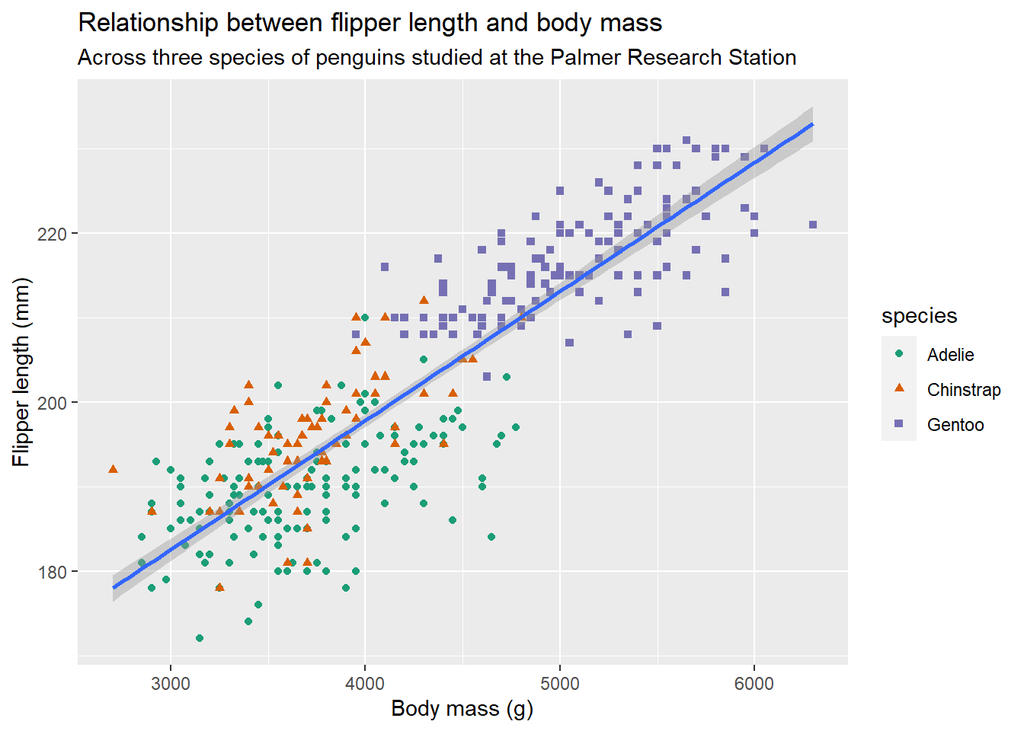